# Generative models | Zihao Wang

[ZW.](https://drzihao.wang/)

[Research](https://drzihao.wang/Research/)

/

RESEARCH / GENERATIVE MODELS

# From stochastic dynamics to reliable inference.

We study how generative models can use shared information, learned dynamics, and physical requirements to produce useful answers to scientific problems.

## Understanding the process of generation

A generative model learns statistical patterns in data and uses them to produce new examples. In a diffusion model, generation unfolds through many small steps: a noisy state is gradually transformed into a structured result. This evolving process offers opportunities to guide what the model produces.

Our research asks how that guidance can be grounded in the problem we want to solve. When translating a medical image, which anatomical information should remain? When moving between imaging modalities, how should the transformation unfold? When reconstructing an unknown object, how should the result agree with the measurements? These questions connect generative learning with statistical inference and scientific modeling.

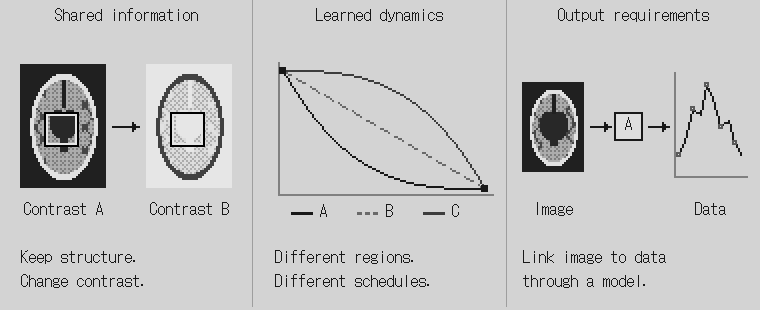

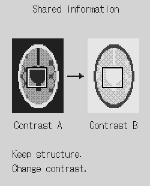

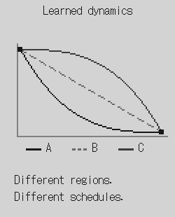

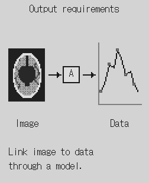

Three complementary questions organize this research: preserve shared information, design the transformation, and connect the result to observations. They describe related research directions with different training and inference settings.

INFORMATION

## Preserve what different views share.

The same anatomy can look very different in two medical scans. Brightness may change while relationships between neighboring tissues still provide useful clues. We use local mutual information to bring these shared statistical relationships into the diffusion process, helping guide the changing image toward a target modality while retaining information from the input.

A model trained on target-modality images can then translate source modalities absent from training, where the local statistical relationships transfer sufficiently well. This also supports reuse of existing analysis tools, such as brain segmentation. [1]

DYNAMICS

## Shape how the transformation unfolds.

Different parts of an image may require different changes. We develop diffusion dynamics in which image regions and channels can follow different learned transition schedules. This gives the model more flexibility to handle the relationships between a source observation and a target representation.

Learned from corresponding image pairs, these transitions support cross-modal generation across MRI, radar-to-optical translation, and industrial inspection. The work connects the learned transition to a continuous-time stochastic model and a sampler, with experiments demonstrating useful translations in fewer denoising steps. [2]

CONSTRAINTS

## Work backward from the required outcome.

Scientific reconstruction begins with measurements. A CT image, for example, should reproduce the recorded X-ray projections when passed through an imaging model. We formulate terminal-conditioned inversion with backward stochastic differential equations, or BSDEs: an output requirement helps determine a suitable state inside a pretrained generative model.

The pretrained prior stays frozen. Reconstruction combines its learned image structure with the observation model. The BSDE formulation has existence and uniqueness guarantees under stated regularity assumptions; its numerical realization is demonstrated on sparse-view CT. [3]

## Reading SDEs and BSDEs through random information

An SDE specifies a starting state and how drift and random shocks move it. A BSDE specifies a terminal random variable and a driver, then determines an adapted pair (Y, Z). Y is the value process; Z describes how new random information changes it.

The distinction concerns what is given and what must be solved. In both cases, information becomes available forward in time. Solving a BSDE backward does not give the process access to future noise.

### The same noise, two different stochastic quantities

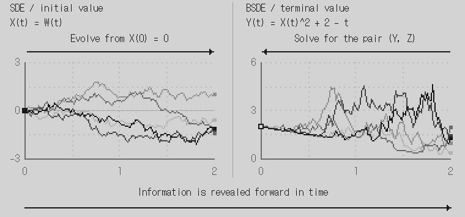

Illustrative Brownian example with T = 2 and zero BSDE driver. The two panels use the same five noise realizations. The terminal rule is Y(T) = X(T)^2; its realized value can differ across paths.

### A conditional-expectation view

For dX = dW and terminal rule Y(T) = X(T)^2, the zero-driver BSDE has the exact solution Y(t) = E[X(T)^2 | F(t)] = X(t)^2 + (T - t), with Z(t) = 2X(t). The term T - t accounts for noise that has not yet been revealed.

### A two-step information tree

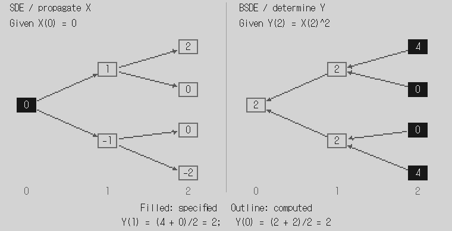

Each branch adds +1 or -1 with probability 1/2. The left tree propagates X. The right tree assigns terminal values X(2)^2, then takes conditional averages at earlier nodes. Vertical position separates histories; it is not a value axis.

Z is also solved for. In this two-step example, Z(0) = 0; after the first step it is -2 on the X(1) = -1 branch and +2 on the X(1) = +1 branch.

This example explains the stochastic-analysis idea. The paper uses a score-induced driver and task-specific terminal specifications. Its BSDE is distinct from the reverse-time SDE used for diffusion sampling. [3]

## Connecting the terminal requirement to a frozen prior

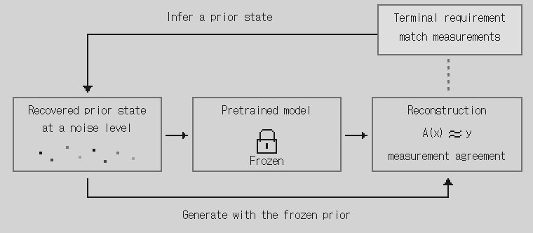

Start with an output requirement, infer a suitable noisy prior state, and generate through the frozen model. In the CT implementation, measurement agreement is optimized numerically at the final image.

### What “backward” means here

The associated BSDE is a terminal-value inference problem, distinct from the reverse-time SDE normally used for diffusion sampling. The theorem concerns the exact BSDE under its assumptions. The CT implementation uses a final measurement-discrepancy objective; it does not establish exact measurement agreement for every numerical reconstruction or generated sample.

## Research behind this overview

1. [Mutual Information Guided Diffusion for Zero-shot Cross-modality Medical Image Translation](https://doi.org/10.1109/TMI.2024.3382043) IEEE Transactions on Medical Imaging, 2024Target-modality training; source modalities absent from training.
2. [Adaptive Domain Shift in Diffusion Models for Cross-Modality Image Translation](https://arxiv.org/abs/2601.18623) ICLR 2026Paired training; learned cross-modal dynamics and sampling.
3. [Backward SDEs-based Diffusion for Physics-Constrained Generation](https://laplacelab.github.io/BSDEDiffusion/) ICML 2026Frozen pretrained prior; terminal-conditioned inversion and CT reconstruction.